# Empirical Project 2

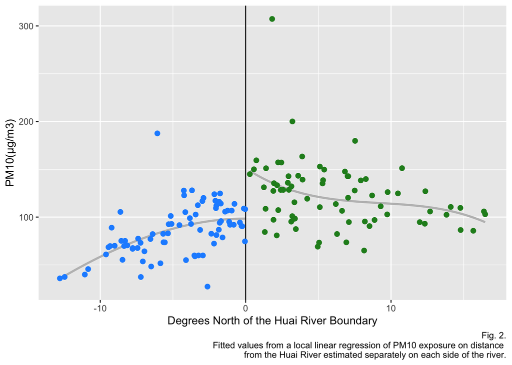

```r
#ok, let's make a ggplot and store them in variables to try to replicate Figure 2 in the paper

g <- ggplot(data = river_bin, aes(x = dist_huai, y = pm10, color = pm10)) + labs(x= "Degrees North of the Huai River Boundary", y = "PM10(μg/m3)", caption ="Fig. 2.
                                                                                   Fitted values from a local linear regression of PM10 exposure on distance
                                                                                   from the Huai River estimated separately on each side of the river.")

#print out our base graph
#g

#make it look nicer, add to base graph
#g1 <- g + geom_point(color = "orange", aplha = 0.5) + scale_color_manual(values= c(""))
g1 <- g + geom_smooth(data = river_data %>% filter(north_huai==0), se = FALSE, method = 'lm', color = "grey", alpha = 0.4, formula = y~poly(x,3))

#keep going

g2 <- g1 + geom_smooth(data = river_data %>% filter(north_huai==1), se = FALSE, method = 'lm', color = "grey", alpha = 0.8, formula =  y~poly(x,3))

gg2 <- g2 + geom_point(data = river_data %>% filter(north_huai==1), color = "forestgreen", size =2)

#add the vertical line at distance zero
g3 <- gg2 + geom_vline(data = river_bin, xintercept = 0, aplha = 0.7)
#some fails
#+ scale_color_manual(aes(x = "North", color = "green"))
#+ geom_point(aes(color="slategrey"))
#+ stat_summary_bin(fun='mean', bins=10, color='black', geom='point') + theme(legend.position = "bottom")

#good layout
g4 <- g3 + geom_point(data = river_data %>% filter(north_huai==0), color = "dodgerblue", size =2)

g4
```

Ok, I’ve made really nice ggplots for scatterplots, but they are obviously not binned. To avoid discarding them, and to explore binning a plot, I’m going to make another attempt below!

```r
#make a new binned dataframe to universally use
river_pm <- huai_data %>% mutate(north_huai_f = as.factor(north_huai))

# Add dist_bin to river_data
river_pm <- huai_data %>% mutate(dist_bin = cut(dist_huai, breaks = seq(-13, 17, by =  1), right = FALSE))

table(river_pm$dist_bin)
```

```
##
## [-13,-12) [-12,-11) [-11,-10)  [-10,-9)   [-9,-8)   [-8,-7)   [-7,-6)   [-6,-5)
##         2         1         1         5         6         7         5         8
##   [-5,-4)   [-4,-3)   [-3,-2)   [-2,-1)    [-1,0)     [0,1)     [1,2)     [2,3)
##         6        10        11        11         9         3         8        10
##     [3,4)     [4,5)     [5,6)     [6,7)     [7,8)     [8,9)    [9,10)   [10,11)
##        12         2         8         5         8         6         3         3
##   [11,12)   [12,13)   [13,14)   [14,15)   [15,16)   [16,17)
##         1         3         1         3         1         2
```

```r
#We have made  our bin intevals, printed below
```

```r
#Just to get a fresh dataset
river <- read_dta("~/Downloads/huairiver.dta")

#Like before,
#add new variable for north haui to be a factor
river <- river %>%
  mutate(north_huai_f = as.factor(north_huai))

#separate bins
river <- river %>%
  mutate(dist_bins = cut(dist_huai, breaks = seq(-13, 17, by = 1),
                              right = FALSE))

#check if the dist_huai_bins variable is a factor variable
is.factor(river$dist_bins)
```

```
## [1] TRUE
```

```r
table(river$dist_bins)
```

```
##
## [-13,-12) [-12,-11) [-11,-10)  [-10,-9)   [-9,-8)   [-8,-7)   [-7,-6)   [-6,-5)
##         2         1         1         5         6         7         5         8
##   [-5,-4)   [-4,-3)   [-3,-2)   [-2,-1)    [-1,0)     [0,1)     [1,2)     [2,3)
##         6        10        11        11         9         3         8        10
##     [3,4)     [4,5)     [5,6)     [6,7)     [7,8)     [8,9)    [9,10)   [10,11)
##        12         2         8         5         8         6         3         3
##   [11,12)   [12,13)   [13,14)   [14,15)   [15,16)   [16,17)
##         1         3         1         3         1         2
```

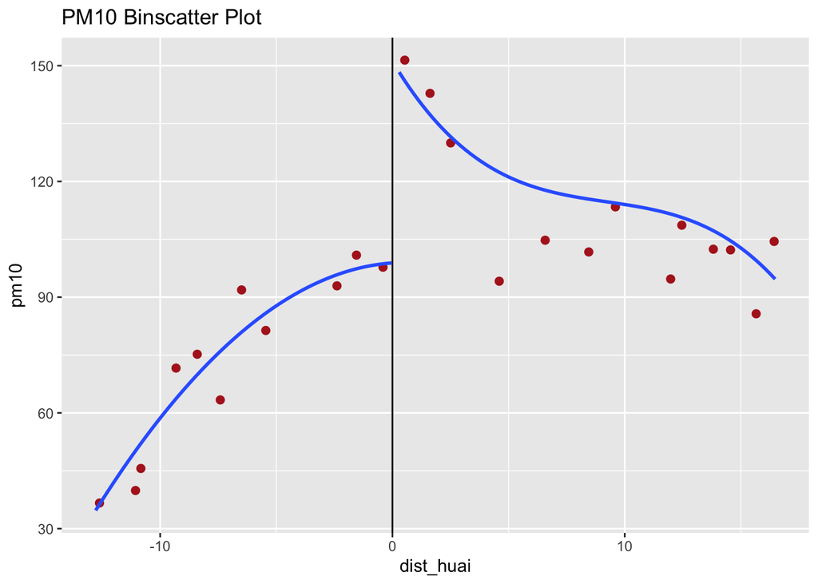

```r
#Great, now plots

pm10_binscatter <- river %>% group_by(dist_bins) %>%
        summarise(dist_huai = mean(dist_huai), pm10 = mean(pm10)) %>%
        ggplot(aes(x = dist_huai, y = pm10)) +
        geom_point(colour = "firebrick", size = 2, alpha = 1) +
        geom_smooth(data = river %>% filter(north_huai_f == 1), se = FALSE,
                    method = "lm", formula = y ~ poly(x, 3)) +
        geom_vline(xintercept = 0) +
        geom_smooth(data = river %>% filter(north_huai_f == 0), se = FALSE,
                    method = "lm", formula = y ~ poly(x, 2)) +
        ggtitle("PM10 Binscatter Plot")

#Print out! Nice!
pm10_binscatter
```

**Graphical Interpretation**

First off, graphically, we can see that we do not have an explicit sharp regression discontinuity design–we have a fuzzy RD design. We can see this near our cutoff of x=0 distance from the Huai River, wherein some variables’ line of best fit seem to seamlessly match up, or have too messy of data points to classify it as sharp. We begin the analysis graphically with an assessment of the Huai River Policy’s impact on pollution. We have plots for PM10 at DSP locations against their degrees north of the Huai River line. The points in represent the average PM10 concentration across DSP locations within 1°-latitude distance bins from the Huai River.

**b. Draw binned scatter plots to test whether (i) temperature, (ii) precipitation, and (iii) wind speed changes at the Huai River line. Display fitted lines (linear, or quadratic, or whatever functional form you see fit) based on what you see in the data.**